# Assignment 9: Spatial Analysis in R

Tasneem Ahsanullah

## OVERVIEW

This exercise accompanies the lessons in Environmental Data Analytics (ENV872L) on spatial analysis.

## Directions

1. Rename this file `<FirstLast>_A09_SpatialAnalysis.Rmd` (replacing `<FirstLast>` with your first and last name).
2. Change “Student Name” on line 3 (above) with your name.
3. Use the lesson as a guide. It contains code that can be modified to complete the assignment.
4. Work through the steps, **creating code and output** that fulfill each instruction.
5. Be sure to **answer the questions** in this assignment document. Space for your answers is provided in this document and is indicated by the “>” character. If you need a second paragraph be sure to start the first line with “>”. You should notice that the answer is highlighted in green by RStudio.
6. When you have completed the assignment, **Knit** the text and code into a single HTML file.

## DATA WRANGLING

### Set up your session

1. Import libraries: tidyverse, sf, leaflet, and mapview
2. Check your working directory

```r
#1.
#Import the tidyverse library
library(tidyverse)
library(lubridate)
library(sf)
```

```r
library(leaflet)
library(mapview); mapviewOptions(fgb = FALSE)

#2.
getwd()
```

```
## [1] "/Users/tasneemahsanullah/Desktop/Classes/EDA/DataAnalytics"
```

### Read (and filter) county features into an sf dataframe and plot

In this exercise, we will be exploring stream gage height data in Nebraska corresponding to floods occurring there in 2019. First, we will import from the US Counties shapefile we’ve used in lab lessons, filtering it this time for just Nebraska counties. Nebraska’s state FIPS code is `31` (as North Carolina’s was `37`).

3. Read the `cb_2018_us_county_20m.shp` shapefile into an sf dataframe, filtering records for Nebraska counties (State FIPS = 31)
4. Reveal the dataset’s coordinate reference system
5. Plot the records as a map (using `mapview` or `ggplot`)

```r
#3. Read in Counties shapefile into an sf dataframe, filtering for just NE counties
ne_counties <- st_read('./Data/Spatial/cb_2018_us_county_20m.shp') %>%
  filter(STATEFP == "31")
#4. Reveal the CRS of the counties features
st_crs(ne_counties)
```

```
## Coordinate Reference System:
##   User input: NAD83
##   wkt:
## GEOGCRS["NAD83",
##     DATUM["North American Datum 1983",
##         ELLIPSOID["GRS 1980",6378137,298.257222101,
##             LENGTHUNIT["metre",1]]],
##     PRIMEM["Greenwich",0,
##         ANGLEUNIT["degree",0.0174532925199433]],
##     CS[ellipsoidal,2],
##         AXIS["latitude",north,
##             ORDER[1],
##             ANGLEUNIT["degree",0.0174532925199433]],
##         AXIS["longitude",east,
##             ORDER[2],
##             ANGLEUNIT["degree",0.0174532925199433]],
##     ID["EPSG",4269]]
```

```r
#5. Plot the data
mapView(ne_counties)
```

[interactive chart not shown]

6. What is the EPSG code of the Counties dataset? Is this a geographic or a projected coordinate reference system? (Or, does this CRS use angular or planar coordinate units?) To what datum is this CRS associated? (Tip: look the EPSG code on https://spatialreference.org)

### Read in gage locations csv as a dataframe, then display the column names it contains

Next we’ll read in some USGS/NWIS gage location data added to the `Data/Raw` folder. These are in the `NWIS_SiteInfo_NE_RAW.csv` file.(See `NWIS_SiteInfo_NE_RAW.README.txt` for more info on this dataset.)

7. Read the NWIS_SiteInfo_NE_RAW.csv file into a standard dataframe.
8. Display the column names of this dataset.

```r
#7. Read in gage locations csv as a dataframe
gage_locations <- read.csv('./Data/Raw/NWIS_SiteInfo_NE_RAW.csv',
                           colClasses = c('site_no' = 'factor'))

#8. Reveal the names of the columns
colnames(gage_locations)
```

```
## [1] "site_no"            "station_nm"         "site_tp_cd"
## [4] "dec_lat_va"         "dec_long_va"        "coord_acy_cd"
## [7] "dec_coord_datum_cd"
```

### Convert the dataframe to a spatial features (“sf”) dataframe

10. Convert the dataframe to an sf dataframe.
- Note: These data use the same coordinate reference system as the counties dataset
11. Display the column names of the resulting sf dataframe

```r
#10. Convert to an sf object
gage_locations.sf <-st_as_sf(gage_locations,
                             coords = c('dec_long_va','dec_lat_va'), crs=4269)


#11. Re-examine the column names
colnames(gage_locations.sf)
```

```
## [1] "site_no"            "station_nm"         "site_tp_cd"
## [4] "coord_acy_cd"       "dec_coord_datum_cd" "geometry"
```

12. What new field(s) appear in the sf dataframe created? What field(s), if any, disappeared?

> ANSWER: New fields are “geometry” and “dec_lat_va” and “dec_long_va” are gone.

### Plot the gage locations on top of the counties

13. Use `ggplot` to plot the county and gage location datasets.
- Be sure the datasets are displayed in different colors
- Title your plot “NWIS Gage Locations in Nebraska”
- Subtitle your plot with your name

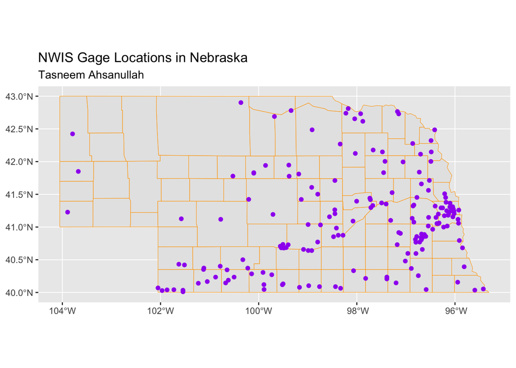

```r
#13. Plot the gage locations atop the county features
ggplot()+
  geom_sf(data=ne_counties,color='orange')+
  geom_sf(data=gage_locations.sf,color='purple') +
  ggtitle("NWIS Gage Locations in Nebraska", subtitle="Tasneem Ahsanullah")
```

### Read in the gage height data and join the site location data to it.

Lastly, we want to attach some gage height data to our site locations. I’ve constructed a csv file listing many of the Nebraska gage sites, by station name and site number along with stream gage heights (in meters) recorded during the recent flood event. This file is titled `NWIS_SiteFlowData_NE_RAW.csv` and is found in the Data/Raw folder.

14. Read in and wrangle the `NWIS_SiteFlowData_NE_RAW.csv` dataset:
- Be sure the `site_no` column is read in as a factor
- Group by `site_no` and `station_nm`, computing the mean `gage_ht` across groups values
15. Show the column names .
16. Join our site information (already imported above) to these gage height data.
- The `site_no` and `station_nm` can both/either serve as joining attributes.
- Construct this join so that the result only includes spatial features where both tables have data.
17. Show the column names in this resulting spatial features object
18. Show the dimensions of the resulting joined dataframe

```r
#14. Read the site flow data into a data frame
#site_no read as factor
#grouped by site_no and station_nm
#mean gage height calculated
ne_flow <- read.csv('./Data/Raw/NWIS_SiteFlowData_NE_RAW.csv',
  colClasses = c('site_no' = 'factor')) %>%
  group_by(site_no, station_nm) %>%
  summarize(
    meanGage = mean(`gage_ht`,na.rm=T))
#checking that site_no is a factor
class(ne_flow$site_no)
```

```
## [1] "factor"
```

```r
#15. Show the column names
colnames(ne_flow)
```

```
## [1] "site_no"    "station_nm" "meanGage"
```

```r
#16. Join the flow data to our NWIS gage location spatial dataframe
flow_gage <- gage_locations.sf %>%
  left_join(ne_flow) %>%
  na.omit()
#17. Show the column names of the joined dataset
colnames(flow_gage)
```

```
## [1] "site_no"            "station_nm"         "site_tp_cd"
## [4] "coord_acy_cd"       "dec_coord_datum_cd" "meanGage"
## [7] "geometry"
```

```r
#18. Show the dimensions of this joined dataset
dim(flow_gage)
```

```
## [1] 118   7
```